# Wine: LiquidAssets: Price regression:: LiquidAssets_Wine_2016

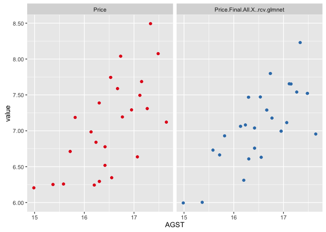

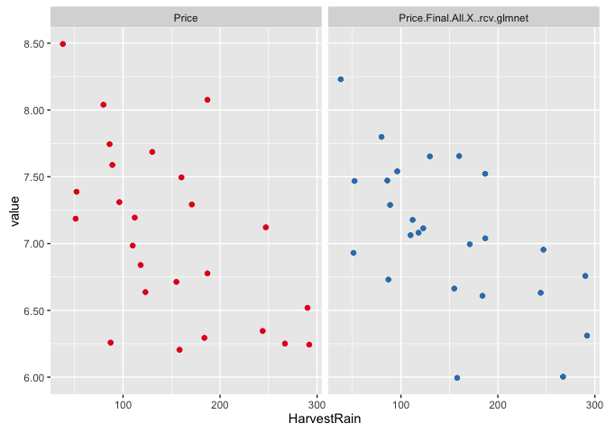

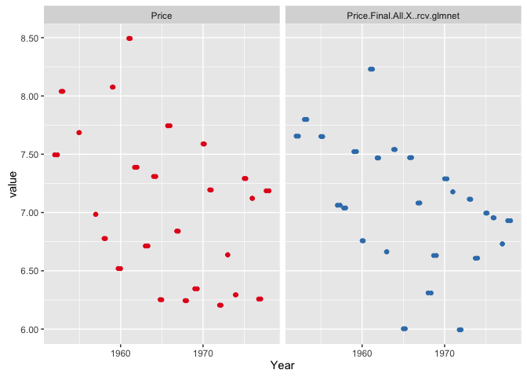

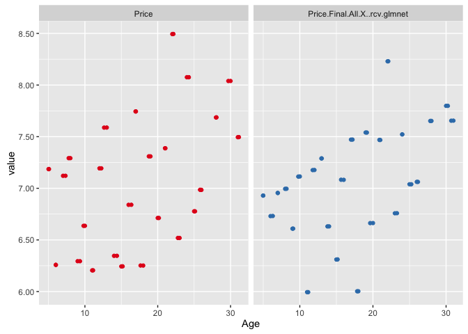

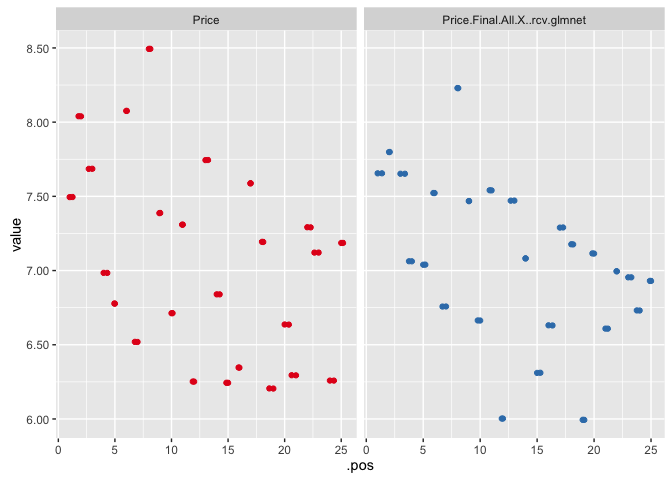

[output not shown]

[output cut: 21 more lines]

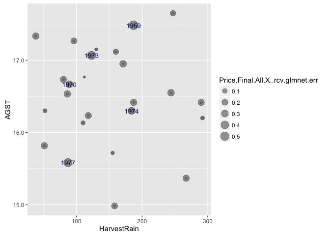

```r
if (glb_is_classification && glb_is_binomial)
    glb_analytics_diag_plots(obs_df=glbObsTrn, mdl_id=glb_fin_mdl_id,
            prob_threshold=glb_models_df[glb_models_df$id == glb_sel_mdl_id,
                                         "opt.prob.threshold.OOB"]) else
    glb_analytics_diag_plots(obs_df=glbObsTrn, mdl_id=glb_fin_mdl_id)
```

```r
dsp_feats_vctr <- c(NULL)
for(var in grep(".imp", names(glb_feats_df), fixed=TRUE, value=TRUE))
    dsp_feats_vctr <- union(dsp_feats_vctr,
                            glb_feats_df[!is.na(glb_feats_df[, var]), "id"])

# print(glbObsTrn[glbObsTrn$UniqueID %in% FN_OOB_ids,
#                     grep(glb_rsp_var, names(glbObsTrn), value=TRUE)])

print(setdiff(names(glbObsTrn), names(glbObsAll)))
```

```
## [1] "Price.Final.All.X..rcv.glmnet"
## [2] "Price.Final.All.X..rcv.glmnet.err"
## [3] "Price.Final.All.X..rcv.glmnet.err.abs"
## [4] "Price.Final.All.X..rcv.glmnet.is.acc"
```

```r
for (col in setdiff(names(glbObsTrn), names(glbObsAll)))
    # Merge or cbind ?
    glbObsAll[glbObsAll$.src == "Train", col] <- glbObsTrn[, col]

print(setdiff(names(glbObsFit), names(glbObsAll)))
```

```
## character(0)
```

```r
print(setdiff(names(glbObsOOB), names(glbObsAll)))
```

```
## character(0)
```

```r
for (col in setdiff(names(glbObsOOB), names(glbObsAll)))
    # Merge or cbind ?
    glbObsAll[glbObsAll$.lcn == "OOB", col] <- glbObsOOB[, col]

print(setdiff(names(glbObsNew), names(glbObsAll)))
```

```
## character(0)
```

```r
#glb2Sav(); all.equal(savObsAll, glbObsAll); all.equal(sav_models_lst, glb_models_lst)
#load(file = paste0(glbOut$pfx, "dsk_knitr.RData"))
#cmpCols <- names(glbObsAll)[!grepl("\\.Final\\.", names(glbObsAll))]; all.equal(savObsAll[, cmpCols], glbObsAll[, cmpCols]); all.equal(savObsAll[, "H.P.http"], glbObsAll[, "H.P.http"]);

replay.petrisim(pn = glb_analytics_pn,
    replay.trans = (glb_analytics_avl_objs <- c(glb_analytics_avl_objs,
        "data.training.all.prediction","model.final")), flip_coord = TRUE)
```

```
## time trans    "bgn " "fit.data.training.all " "predict.data.new " "end "
## 0.0000   multiple enabled transitions:  data.training.all data.new model.selected    firing:  data.training.all
## 1.0000    1   2 1 0 0
## 1.0000   multiple enabled transitions:  data.training.all data.new model.selected model.final data.training.all.prediction   firing:  data.new
## 2.0000    2   1 1 1 0
## 2.0000   multiple enabled transitions:  data.training.all data.new model.selected model.final data.training.all.prediction data.new.prediction   firing:  model.selected
## 3.0000    3   0 2 1 0
## 3.0000   multiple enabled transitions:  model.final data.training.all.prediction data.new.prediction     firing:  data.training.all.prediction
## 4.0000    5   0 1 1 1
## 4.0000   multiple enabled transitions:  model.final data.training.all.prediction data.new.prediction     firing:  model.final
## 5.0000    4   0 0 2 1
```

[figure not shown]

```r
glb_chunks_df <- myadd_chunk(glb_chunks_df, "predict.data.new", major.inc = TRUE)
```

```
##                label step_major step_minor label_minor    bgn    end
## 21 fit.data.training          9          1           1 65.382 69.956
## 22  predict.data.new         10          0           0 69.957     NA
##    elapsed
## 21   4.574
## 22      NA
```

## Step `10.0: predict data new`

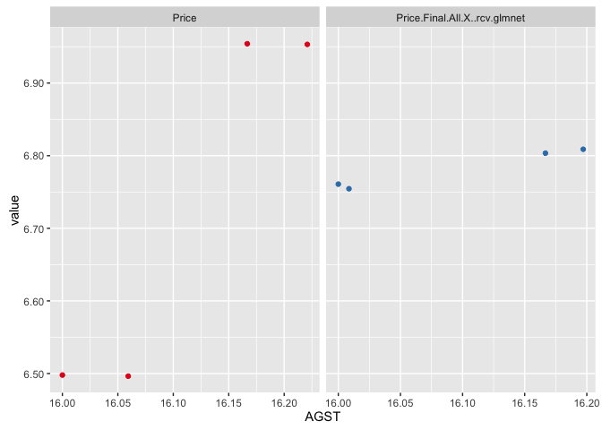

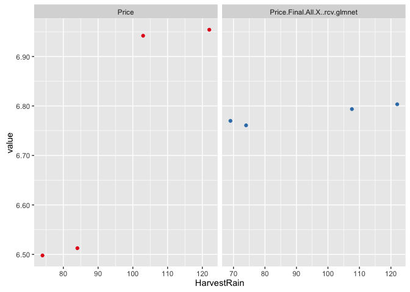

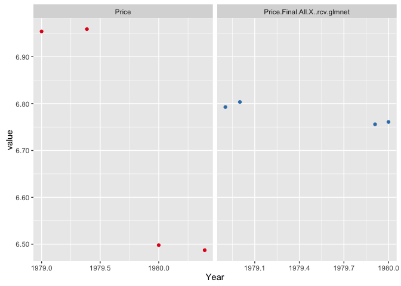

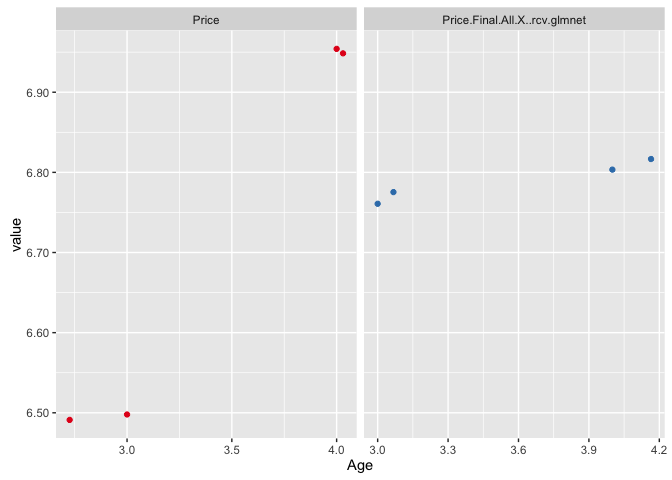

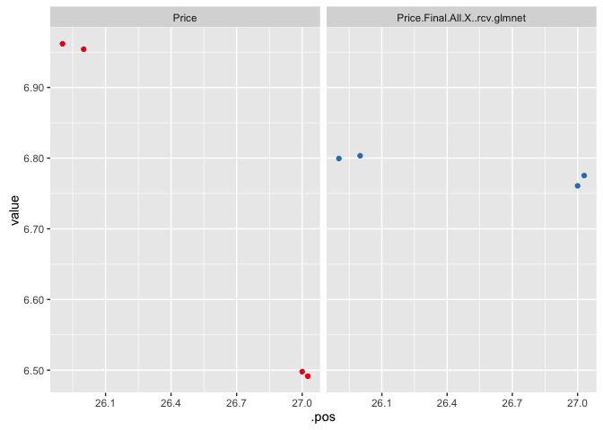

```
##    Year  Price WinterRain    AGST HarvestRain Age FrancePop .src
## 27 1980 6.4979        578 16.0000          74   3  55110.24 Test
## 26 1979 6.9541        717 16.1667         122   4  54835.83 Test
##          .rnorm .pos .pos.y .lcn .category Price.Final.All.X..rcv.glmnet
## 27 -0.006982463   27     27  OOB    .dummy                      6.760825
## 26 -0.816487211   26     26  OOB    .dummy                      6.803422
##    Price.Final.All.X..rcv.glmnet.err Price.Final.All.X..rcv.glmnet.err.abs
## 27                         0.2629247                             0.2629247
## 26                         0.1506782                             0.1506782
##    Price.Final.All.X..rcv.glmnet.is.acc .label
## 27                                FALSE   1980
## 26                                FALSE   1979
```

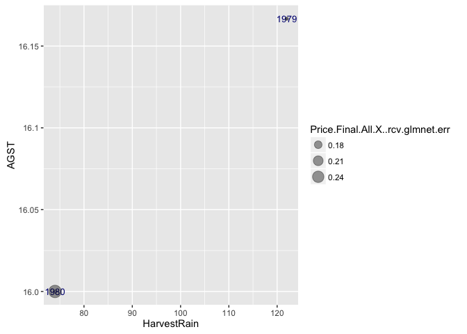

```
## [1] TRUE
```

```
## [1] "glb_sel_mdl_id: All.X##rcv#glmnet"
```

```
## [1] "glb_fin_mdl_id: Final.All.X##rcv#glmnet"
```

```
## [1] "Cross Validation issues:"
## Max.cor.Y.rcv.1X1###glmnet
##                          0
```